# Equity checks on effort-sharing framework

Khoo Wei Yang

18/09/2023

Following the fair share comparison, this analysis intend to test the CERF framework for equity principles. According to [Ringius et al. (2002)](https://link.springer.com/article/10.1023/A:1015041613785), any climate effort-sharing regimes can follow largely four principles. To be equitably grounded, the regime need to redistribute costs and benefits according to responsibility, capability, and needs. In a crude way, we can check the boxes of these criteria by looking at:  
1. how the framework allocate mitigation burdens, i.e., does it accord burden proportionally to responsibility and capability?  
2. how does the framework address needs, i.e., does the framework allocate equitable climate space for those in need of an acceptable amount of emissions allowance to develop?

The analysis structures as follows:  
1. We first check the proportionality of effort allocation and baseline emissions of each country. We check if there is grandfathering of emissions allowance, i.e., bigger emitters get more allowance, which can crop up in inequitable regimes.  
2. As emissions distribution in largely unequal, we check if the effort allocation system, which incur reduction obligations on countries, much like a tax system. We assess if the system can redistribute the constrained climate space, in other words, correct for the imbalances in an emissions distribution?  
3. Finally we check if the framework accommodate the needs of groups below development threshold to meet their developmental needs. We do this by checking balances of emissions allowance for groups, comparing it with the share of population below the defined development threshold. We can also check this development threshold against poverty line population.

# Preparing the data

```r
# as proxy of absolute responsibility, we look at cumulative emissions until 2030
#* relative responsibility = country cum emissions/sum of global cum. emissions
## create cumulative emissions variable

cum_base_emissions <- aggregate(df.sliced.wfs$base_emissions_mtco2e,
                                by = list(df.sliced.wfs$iso3), FUN=sum)
colnames(cum_base_emissions)[1] <- "iso3"
colnames(cum_base_emissions)[2] <- "cum_base_emissions_mtco2e"

# map on cumulative emissions
df.countries$cum_base_emissions_mtco2e <-
  cum_base_emissions$cum_base_emissions_mtco2e[match(df.countries$iso3, cum_base_emissions$iso3)]

df.region$cum_base_emissions_mtco2e <-
  cum_base_emissions$cum_base_emissions_mtco2e[match(df.region$iso3, cum_base_emissions$iso3)]

df.big6$cum_base_emissions_mtco2e <-
  cum_base_emissions$cum_base_emissions_mtco2e[match(df.big6$iso3, cum_base_emissions$iso3)]

#* to understand current capacity compared against projected effort, we look at current rather than
#* projected economic size, for this we take 2019 USD PPP as a proxy.
## extract 2019 GDP into new df

cum_base_emissions$GDP_blnUSDPPP <- df.sliced.wfs[match(df.sliced.wfs$iso3, cum_base_emissions$iso3) & df.sliced.wfs$year == 2019, "gdp_blnUSDPPP"]
```

# 1. Assessing grandfathering

We first look at the baseline cumulative emissions (proxy responsibility) and respective GDP per capita PPP (proxy capacity). This give us an overview of the proportionality of emissions and economic size.

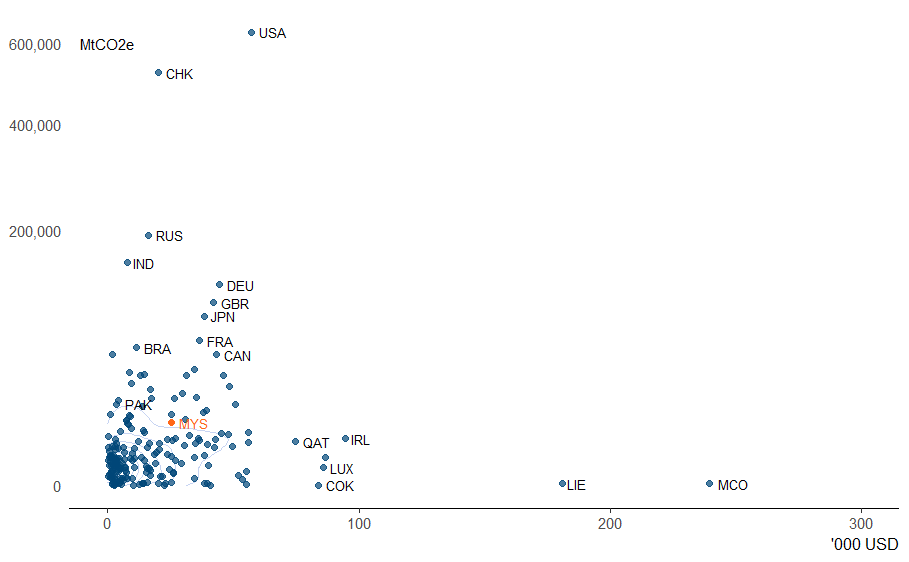

This is easier to observe in a bivariate plot, where the fitted line shows more or less diagonal proportionality, albeit a skewed distribution. This skew indicates a few countries have emitted disproportionately more than the collective of other countries, most of which also have smaller economic sizes.

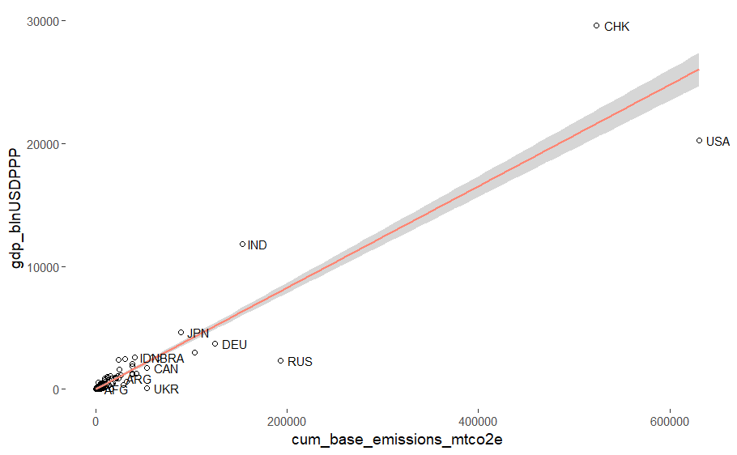

```r
# plot bivariate point graph

ggplot(df.countries, aes(x = cum_base_emissions_mtco2e, y = gdp_blnUSDPPP, label = iso3)) +
  geom_point(shape = 21) +
  geom_smooth(method = "lm",
              linewidth = .6,
              color = "#ff8674") +
  geom_text(check_overlap = T,
            size = 3,
            hjust = -.3) +
  theme(panel.background = element_blank(),
        )
```

Because of the high responsibility and capacity of a few countries, we assume the distribution of allocated burden/effort to also be skewed. However, we check if the distribution is positively or negatively skewed. As higher share of burden should accrue to the higher responsible (which are a few), we expect a fair burden sharing to have a long right tail, with higher shares accruing to little. We also check if the distribution of cumulative emissions (responsibility) is similar to the distribution of allocation.

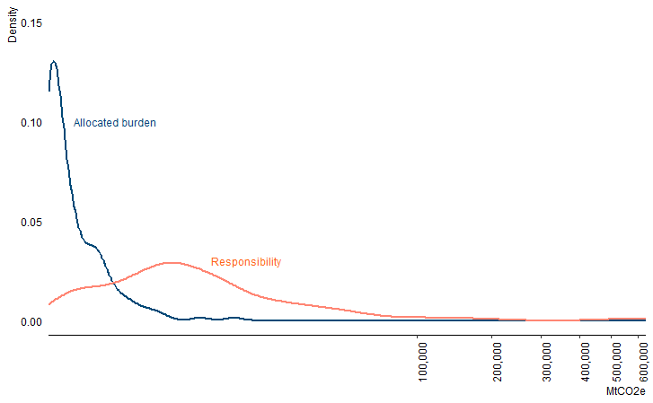

The distribution of fair share (blue density curve) follows but exhibit a more skewed distribution when compared to cumulative emissions distribution. This means that a higher amount of emissions reduction (axis x) is accorded to very few countries, while most countries (as the peak of the density curve) take on less burden.

We also plot bivariate kernel density to show the spread of countries’ responsibility and their fair share parity.

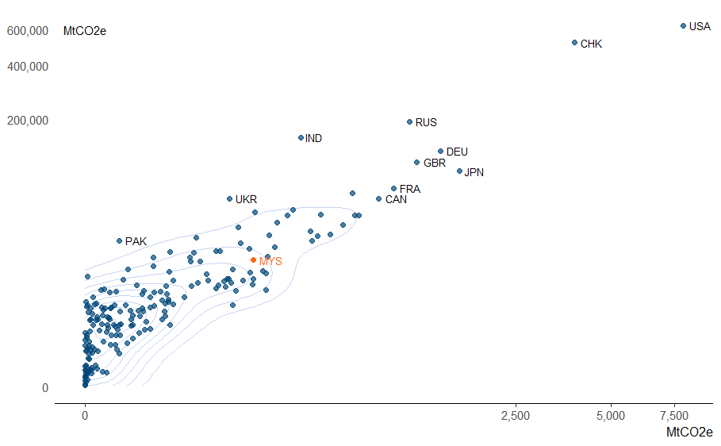

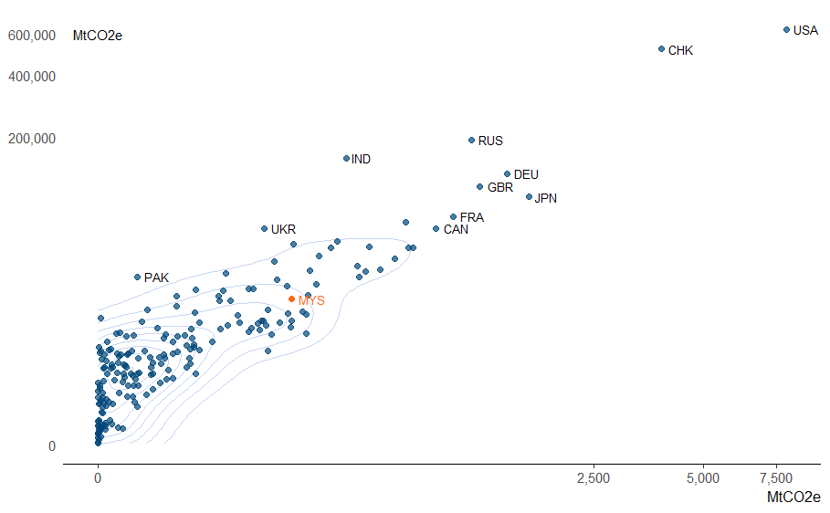

```r
#boxcox-transform to show details in 1 - 100 MtCO2e
ggplot(df.countries, aes(x = fs_rdxn_mtco2e, y = cum_base_emissions_mtco2e, label = iso3)) +
  geom_density2d(color = "#8FAAE5",
                 alpha = 0.5) +
  geom_point(shape = 19,
             color = "#004678",
             alpha = .7
             ) +
   geom_point(data = highlight_df,
              aes(x = fs_rdxn_mtco2e, y = cum_base_emissions_mtco2e, label = iso3),
              shape = 19,
              color = "#ff6718"
             ) +
  geom_text(data =  df.countries[df.countries$iso3 %in% country_to_label,],
            aes(x = fs_rdxn_mtco2e, y = cum_base_emissions_mtco2e, label = iso3),
            check_overlap = T,
            size = 2.7,
            hjust = -.3) +
  geom_text(data =  df.countries[df.countries$iso3 == "MYS",],
            aes(x = fs_rdxn_mtco2e, y = cum_base_emissions_mtco2e, label = iso3),
            check_overlap = T,
            size = 2.7,
            hjust = -.3,
            color = "#ff6718") +
  annotate("text", x = 0, y = 600000, label = "MtCO2e", size = 3) +
  xlab("MtCO2e") +
  scale_x_continuous(trans = modulus_trans(.25), labels = scales::comma) +
  scale_y_continuous(trans = modulus_trans(.25), labels = scales::comma) +
  theme(panel.background = element_blank(),
        axis.line.x = element_line(linewidth = .5),
        axis.ticks.y = element_blank(),
        axis.title.y = element_blank(),
        axis.title.x = element_text(hjust = 1, size = 9))
#boxcox-transform to show details in 1 - 100 MtCO2e
ggplot(df.countries, aes(x = fs_rdxn_mtco2e, y = cum_base_emissions_mtco2e, label = iso3)) +
  geom_density2d(color = "#8FAAE5",
                 alpha = 0.5) +
  geom_point(shape = 19,
             color = "#004678",
             alpha = .7
             ) +
   geom_point(data = highlight_df,
              aes(x = fs_rdxn_mtco2e, y = cum_base_emissions_mtco2e, label = iso3),
              shape = 19,
              color = "#ff6718"
             ) +
  geom_text(data =  df.countries[df.countries$iso3 %in% country_to_label,],
            aes(x = fs_rdxn_mtco2e, y = cum_base_emissions_mtco2e, label = iso3),
            check_overlap = T,
            size = 2.7,
            hjust = -.3) +
  geom_text(data =  df.countries[df.countries$iso3 == "MYS",],
            aes(x = fs_rdxn_mtco2e, y = cum_base_emissions_mtco2e, label = iso3),
            check_overlap = T,
            size = 2.7,
            hjust = -.3,
            color = "#ff6718") +
  annotate("text", x = 0, y = 600000, label = "MtCO2e", size = 3) +
  xlab("MtCO2e") +
  scale_x_continuous(trans = modulus_trans(.25), labels = scales::comma) +
  scale_y_continuous(trans = modulus_trans(.25), labels = scales::comma) +
  theme(panel.background = element_blank(),
        axis.line.x = element_line(linewidth = .5),
        axis.ticks.y = element_blank(),
        axis.title.y = element_blank(),
        axis.title.x = element_text(hjust = 1, size = 9))

ggsave("fs_emi_cntrs_bivariate_distr.svg", device = "svg", width = 15, height = 11, unit = "cm")
```

Both distribution plot indicate higher fair share reduction for higher emissions countries. There are caveats to this approach, (1) country oriented distribution omit status of parties. For example, EU27 negotiate as a group in UNFCCC, we thus have to consider them as a collective. We do this in the below section. (2) Another caveat is that we assess the amount of reduction that is allocated at 2030, it is possible to cumulatively aggregate the annual reduction to give a more complete view of allocation, but we assess only the end-point of fair share for this analysis.

# 2. Assessing redistribution

### Redistributive power of fair share framework

In a lot of ways, country emissions distribution behave like an income distribution, where a small percentage of individuals and countries emit (earn) a lot more than most. Following the lorenz method, we can imagine emissions as an income distribution, and fair share as a tax. A fair tax system would be progressive, and allocate more burden on those who have appropriated more carbon space. We check this by finding the Gini coefficient, where a more progressive allocation would align to or be more concave than the normal lorenz curve ([Norregaard, 1990](https://www.oecd.org/tax/public-finance/35372059.pdf)).

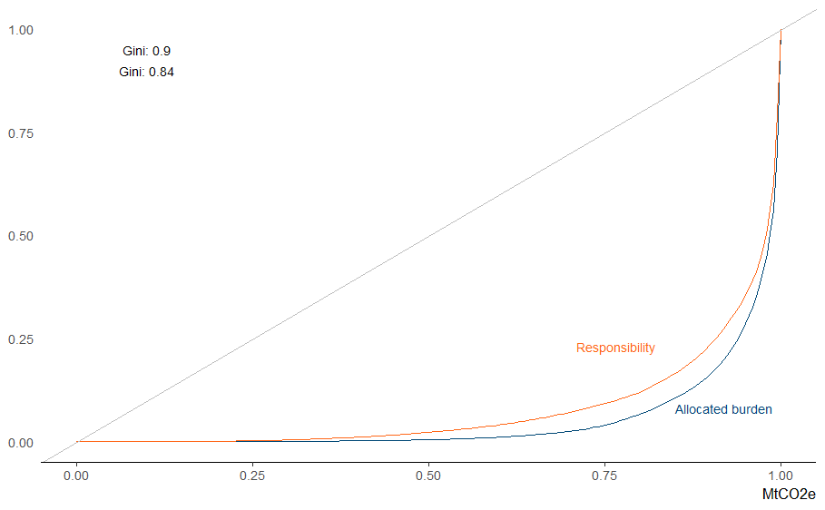

# 3. Needs-based redistribution

Unlike a tax system whose purpose is to redistribution and equalize social outcomes, we might expect recompensation in an effort-sharing system, where emissions of some countries are allowed to grow and some are required to make space for that growth in order to meet developmental needs. CERF based this on the capabilities of a country, defined as the income share that is above a set development threshold. We use an annual income of 7500 USD PPP as a static development threshold, we can calibrate the progressivity by staggeringly include income above this threshold to contribute to mitigation but in this analysis we do not.

To start, we plot the emissions allowance graph for all countries.

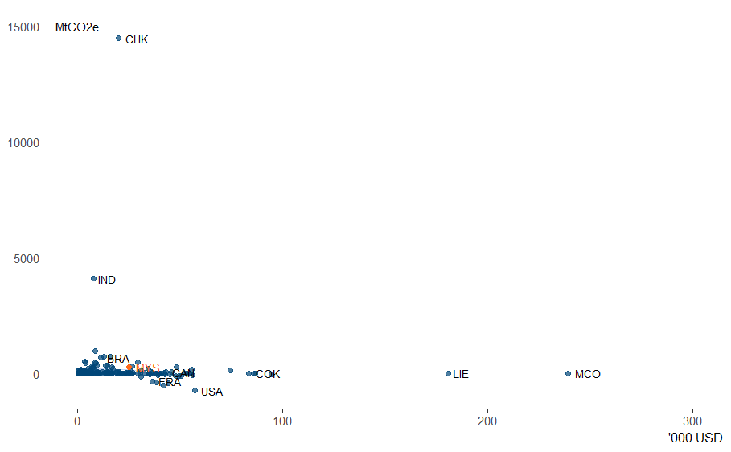

The emissions allowance graph shows that more than half of the world are given room to emit in 2030, wherein China and India are given the most emission space, within the constrain of carbon budget. Whereas countries like USA and those in EU27 are required to produce negative emissions to make room for growth in developing countries.

```r
ggplot(df.countries, aes(x = 1-(pop_mln_above_dl/pop_mln))) +
  geom_density(color = "#004876",
               fill = "#8cbede",
               linewidth = 0.8) +
  geom_point(shape = 21) +
  labs(y = "MtCO2", x = "ratio") +
  scale_y_continuous(expand = c(0,0), limits = c(0, 1.5)) +
  scale_x_continuous(expand = c(0,0)) +
  theme(panel.background = element_blank(),
        axis.title.x = element_text(hjust =1),
        axis.title.y = element_text(angle = 0,
                                    hjust = 1),
        axis.ticks.y = element_blank(),
        axis.line.x = element_line(linewidth = .75))
```

[output not shown]

[output not shown]

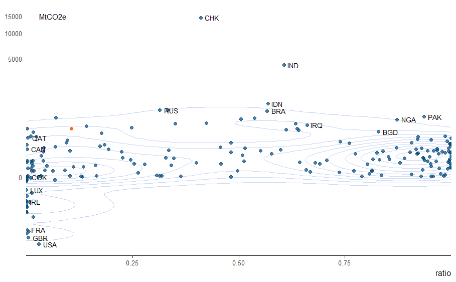

Emissions allowance is the difference between a country’s absolute emissions baseline, and its reduction obligation (which is the product of RCI and baseline emissions), it is a function of the trajectory of current emissions and individual rights to emission space, population is necessary coefficient. To adjust for this we look at allowances per capita of world carbon space.

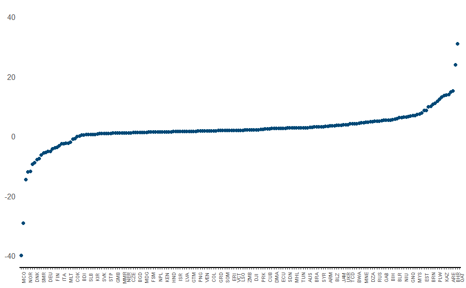

The produced plot shows that in per capita terms, the framework allocate a large part of the world the same amount of emissions allowance. This meant that the high emissions allowance accorded to China and India is a function of their big population. We plot a bivariate plot to see the relationship between capacity and per capita allowance and per capita reduction allocation.

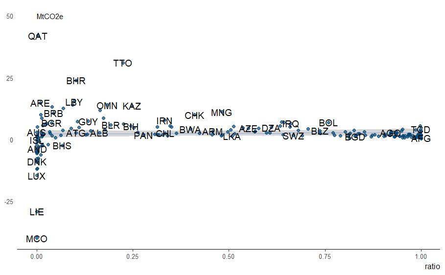

# Annex. bloc analysis

As mentioned above, some countries negotiate as a bloc therefore their fair shares should be accounted together. We compare first the generic groupings of big 6 emitters.

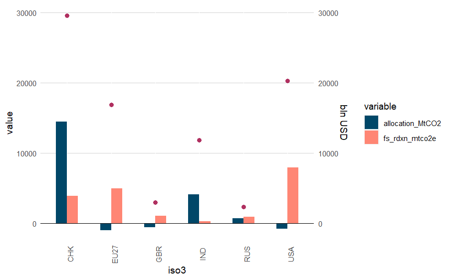

As shown in the graph, China and India receives the biggest emissions allowance for their respective developmental needs. However, it is arguable there exist between them a level of grandfathering as India has a higher population count and higher population below development threshold. However, it is also ture that China is allocated with a higher reduction obligation. While EU27, USA, and GBR all are required to reduce their emissions to negative, Britain is allocated with a lower reduction obligation. This is likely due to unaccounted cumulative responsibility of the country over its colonial history. For this we look at the relationship between historical cumulative emissions and reduction obligation.

```r
ggplot(df.big6, aes(x = fs_rdxn_mtco2e, y = cum_base_emissions_mtco2e, label = iso3)) +
  geom_smooth(method = "lm",
              color = "#004768") +
  geom_point(shape = 20,
             size = 3,
             color = "#ff8674") +
  geom_text(hjust = "inward") +
  scale_x_continuous(expand = c(0,0)) +
  scale_y_continuous(expand = c(0,0)) +
  theme(panel.background = element_blank(),
        axis.text.x = element_text(angle = 90))
```

[output not shown]